# STAT331 Final Project Report

- Show All Code
- Hide All Code
- View Source

Author

Thien An Tran, Tejasree Kandibanda, Matthew Huang, Chloe Anbarcioglu

# Introduction

For our project, we want to explore the relationship between murder rate and happiness score in each country per year. We hypothesize that there will be a negative correlation between the two meaning that the higher the murder rates, the lower happiness scores. This could potentially indicate that safety and security are significant factors in overall happiness.

We obtained our data from Gapminder (n.d.).

> **population**: contains total population counts for each country per year.  
> **murder**: contains total number of estimated deaths from interpersonal violence for each country per year.  
> **happiness**: contains happiness score (converted to 0 to 100 scale to be in terms of percentage) for each country per year.

# 1. Data Cleaning

In order to find the relationship between murder rates and happiness score for each country per year, we need to merge the total murders data set and population data set. That way, we can get the murder rate per 100K people.

**Note**

We first have to convert all the values into numbers (i.e. fix cases such as `1.1k` to be `1100`).

```r
convert_value <- function(val) {
  val <- as.character(val)

  multiplier <- case_when(
    str_detect(val, "k") ~ 1e3,
    str_detect(val, "M") ~ 1e6,
    str_detect(val, "B") ~ 1e9,
    TRUE ~ 1
  )

  numeric_value <- as.numeric(str_remove_all(val, "[kMB]"))

  return(numeric_value * multiplier)
}

murder_clean <- murder |>
  select(country, `2005`:`2019`) |>
  pivot_longer(cols = `2005`:`2019`,
               names_to = "year",
               values_to = "murder_count") |>
  mutate(across(murder_count, ~convert_value(.)))

murder_clean

population_clean <- population |>
  select(country, `2005`:`2019`) |>
  pivot_longer(cols = `2005`:`2019`,
               names_to = "year",
               values_to = "population") |>
  mutate(across(population, ~convert_value(.)))

population_clean
```

[output not shown]

After cleaning the total murders and population data set, we can proceed to merging them to get a data set of the murder rate per 100k people for each country and year. We can then use pivot longer to transform the happiness score data set and merge it with the murder rate per 100k data set to get our final data set.

```r
murder_pop_merged <- murder_clean |>
  inner_join(population_clean, by = c("country", "year"))

murder_rate_clean <- murder_pop_merged |>
  mutate(murder_rate_per_100k = (murder_count / population) * 100000)

happiness_clean <- happiness |>
  select(country, `2005`:`2019`) |>
  pivot_longer(cols = `2005`:`2019`,
               names_to = "year",
               values_to = "happiness_score") |>
   drop_na(happiness_score)

happiness_merged <- murder_rate_clean |>
  inner_join(happiness_clean, by = c("country", "year"))

happiness_merged |>
  head() |>
  knitr::kable(digits = 4)
```

[output not shown]

## Final Dataset

The final data set contains 1,820 rows and 6 columns.

The columns are `country`, `year`, `murder_count`, `population`, `murder_rate_per_100k`, and `happiness_score`.

It provides a comprehensive overview of the murder rates and happiness scores across various countries and years. Each entry in the data set corresponds to a unique combination of a country and a year ranging from 2005 to 2019.

# 2. Linear Regression

In this part, we will use linear regression to model the relationship between our two quantitative variables, murder rate and happiness score. We want to see if our hypothesis from above holds true and whether there is a negative correlation between the two variables.

## Data Visualizations

Here, we will be creating two data visualizations that explore the relationship between our two quantitative variables. Through creative visualizations, we aim to gain a deeper understanding of the relationship between the variables and uncover any interesting patterns or trends that may emerge over time and across countries.

### Relationship between Murder Rate and Happiness Score Over Time

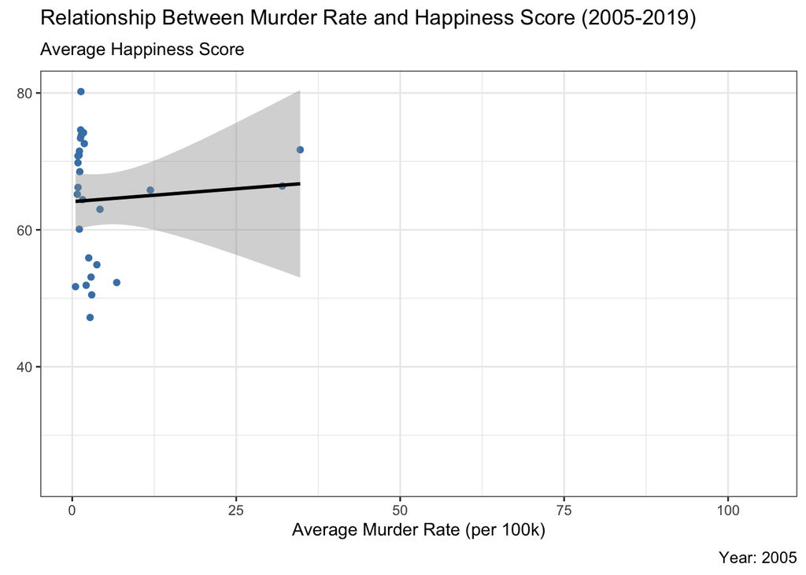

```r
murder_happiness_summary <- murder_happiness |>
  group_by(country, year) |>
  summarise(avg_murder_rate = mean(murder_rate_per_100k),
            avg_happiness_score = mean(happiness_score)) |>
  ungroup()

animated_plot <- ggplot(murder_happiness_summary,
                        aes(x = avg_murder_rate,
                            y = avg_happiness_score)) +
  geom_point(color = "steelblue") +
  geom_smooth(method = "lm", color = "black") +
  labs(title = "Relationship Between Murder Rate and Happiness Score (2005-2019)",
       subtitle = "Average Happiness Score",
       x = "Average Murder Rate (per 100k)",
       y = "",
       caption = "Year: {round(frame_time)}") +
  transition_time(year) +
  enter_fade() +
  exit_fade() +
  theme_bw() +
  theme(plot.caption = element_text(size = 10))

animate(animated_plot, renderer = gifski_renderer())
```

In this visualization, we have plotted the murder rate per 100k people versus the happiness score from 2005 to 2019 for each country. Contrary to our initial prediction of seeing a negative correlation, as in having lower murder rates for a higher happiness score, we see that there’s not much of a correlation between the two. The average murder rate is mostly between 0%-25% for each year and the happiness score has a wide range from 20-80 with no apparent correlation.

### Relationship Between Murder Rate and Happiness Score

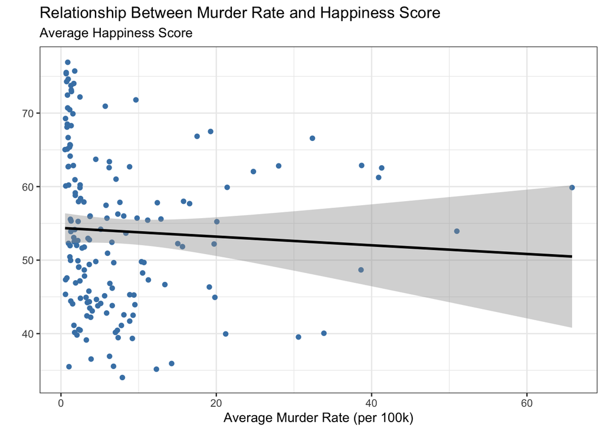

```r
country_murder_happiness <- murder_happiness |>
  group_by(country) |>
  summarise(avg_murder_rate = mean(murder_rate_per_100k),
            avg_happiness_score = mean(happiness_score))

country_murder_happiness |>
  ggplot(aes(x = avg_murder_rate,
             y = avg_happiness_score)
         ) +
    geom_point(color = "steelblue") +
    geom_smooth(method = "lm", color = "black") +
    labs(title = "Relationship Between Murder Rate and Happiness Score",
         subtitle = "Average Happiness Score",
         x = "Average Murder Rate (per 100k)",
         y = "") +
    theme_bw()
```

This plot shows the relationship between the average murder rate per 100k for each country and their overall happiness score. Similar to our previous plot, there is not much correlation between the murder rate and happiness such as an increasing or decreasing happiness score based on the rate of murder.

## Linear Regression

We will be using linear regression as a statistical method to model the relationship between murder rate and happiness score. Then we will use this to evaluate the model fit.

> **x (explanatory)**: average murder rate per 100K people  
> **y (response)**: average happiness score

```r
linear_model <- lm(avg_happiness_score~avg_murder_rate, country_murder_happiness)
broom::tidy(linear_model) |>
  knitr::kable(digits = 4)
```

| term | estimate | std.error | statistic | p.value |
| --- | --- | --- | --- | --- |
| (Intercept) | 54.3774 | 1.050 | 51.7868 | 0.0000 |
| avg_murder_rate | -0.0591 | 0.083 | -0.7119 | 0.4776 |

**Predicted Happiness Score = 54.3774 - 0.0591 x Average Murder Rate**

According to the linear regression model, when the murder rate is zero, the predicted happiness score is estimated to be 54.3774. Additionally, the analysis suggests that for each additional murder per 100,000 people, the predicted happiness score decreases by approximately 0.0591 points.

## Model Fit

```r
var_response <- var(country_murder_happiness$avg_happiness_score)
var_fitted <- var(linear_model$fitted.values)
var_resid <- var(linear_model$residuals)
explained_variation <- var_fitted/var_response

table_data <- data.frame(
  Variable = c("Response Variable Variance", "Fitted Values Variance", "Residuals Variance", "Explained Variation"),
  Value = c(var_response, var_fitted, var_resid, explained_variation)
)

table_data |>
  knitr::kable(digits = 4)
```

| Variable | Value |
| --- | --- |
| Response Variable Variance | 114.7320 |
| Fitted Values Variance | 0.3622 |
| Residuals Variance | 114.3697 |
| Explained Variation | 0.0032 |

The explained variation is 0.00315, which is almost 0. This means that murder rate explains almost none of the variability in happiness. Almost all of the variability in happiness is unaccounted for.

# 3. Simulation

In this section, we aim to evaluate the performance of our linear regression model by comparing the observed data to simulated data generated using the model’s predictions. By simulating data in this manner, we can assess how well the linear regression model captures the underlying relationship between the explanatory and response variables.

## Visualizing Simulations from the Model

The comparison between the observed and simulated data will be visualized through side-by-side plots showcasing the relationships modeled by the linear regression for both data sets.

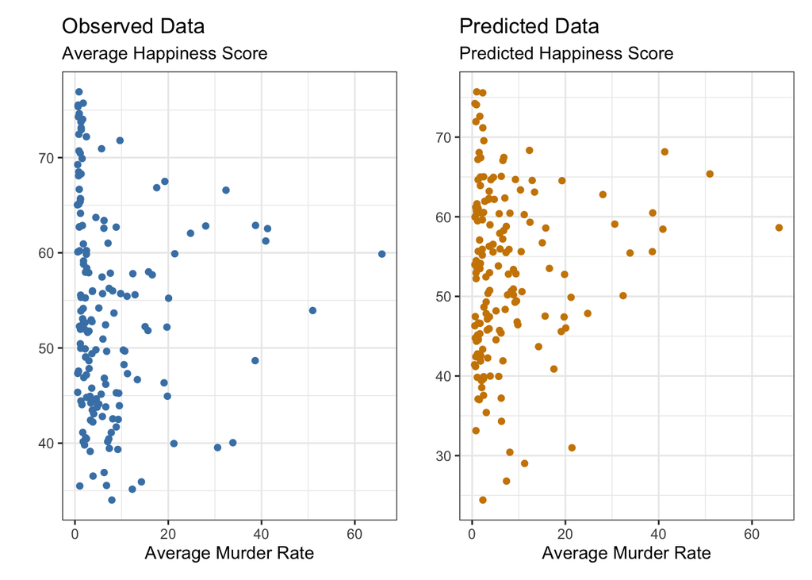

```r
predictions <- predict(linear_model, country_murder_happiness)
residual_se <- sigma(linear_model)
simulated_y <- predictions + rnorm(n = length(predictions), mean = 0, sd = residual_se)

observed <- ggplot(country_murder_happiness,
             aes(x = avg_murder_rate,
                 y = avg_happiness_score)
             ) +
  geom_point(color = "steelblue") +
  labs(title = "Observed Data",
       subtitle = "Average Happiness Score",
       x = "Average Murder Rate",
       y = "") +
  theme_bw()

# Plot Simulated Data
predicted <- ggplot(country_murder_happiness,
             aes(x = avg_murder_rate,
                 y = simulated_y)
             ) +
  geom_point(color = "orange3") +
  labs(title = "Predicted Data",
       subtitle = "Predicted Happiness Score",
       x = "Average Murder Rate",
       y = "") +
  theme_bw()

observed + predicted
```

## References

n.d. https://www.gapminder.org/data/.